# Lab: Conjoint analysis (rating based)

Jimmy Azar

## Introduction

In this lab, we will explore conjoint analysis of a survey consiting of ratings on a Likert scale. Assume you are marketing relationships for a dating website. The “product” in this case represents candidate profiles. A client is presented with a questionnaire to fill (attached) with the purpose of helping you gain insight on their preferences in terms of which attributes are most important to them in a candidate.

Candidates are described based on five attributes consisting of three levels each. The attributes are: *Career* (Business, Fine Arts, or Science), *Fitness* (Not fit; Somewhat fit, or Very fit), *Sense of humor* (Serious, Somewhat funny, or Very funny), *Religiosity* (Not religious, Somewhat religious, or Very religious), and *Matching interests* (Identical, Share some, Very different).

To model their preferences, a client is presented with hypothetical profiles of 18 candidates and needs to rate these profiles on a scale of 1-5 where 1 indicates strong dislike and 5 indicates strong like. The profiles are found in the file “survey_questionnaire”.

In this lab, you will be modeling your own ratings. Therefore, open the file “survey.csv” in a spreadsheet program, add a column named “Rating”, and fill in your ratings on a scale from 1-5 for each row (candidate profile). Save the file as a csv file.

You will then use these responses to understand the relative importance of the five attributes; since these are your own responses, you might be able to validate this qualitatively.

## Fitting a linear model

Load the csv file that you had saved and which contains your ratings for the 18 provided profiles (hint: `read.csv()`).

One of the simplest approaches for modeling your responses is through a linear model over the five predictor variables. Use `lm()` to fit a linear model to the data. The target variable we wish to predict is the rating, whereas all the remaining ones are predictor variables; we specify this using the formula format in `lm()`.

```
model <- lm(Rating ~ Career+Fitness+Humor+Religiosity+Interests, data = data) #linear model
summary(model)
```

The attribute levels that do not appear in the summary table are reference levels. For example, “Business” is a reference level. What can you conclude from looking at the sign and magnitude of the estimated coefficients?

Using the trained model, you can actually make rating predictions for new profiles, however, we are interested in quantifying the relative importance of the 5 attributes based on your ratings of the 18 profiles.

## Attribute importance

In quantifying attribute importance, we will first plot the coefficients for a given attribute (e.g. Career) as a function of the attribute levels (Business, Fine Arts, Science). Since there are 5 attributes, we will be creating 5 plots, one for each attribute. Note that the coefficients appear in `model$coefficients` (these coefficients are equal to zero for reference levels not appearing in the table).

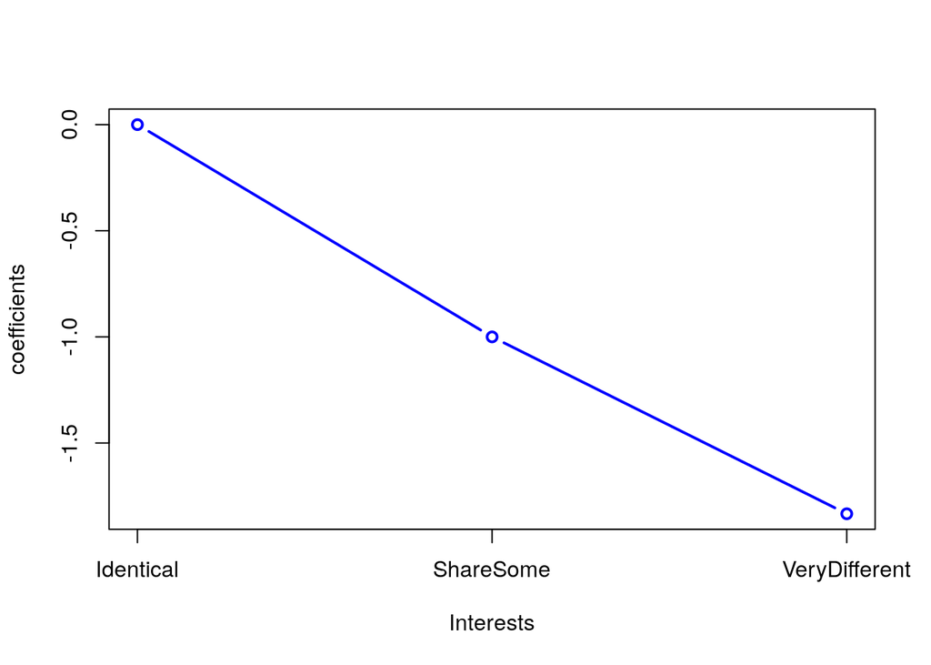

Automate the plotting of the coefficients as a function of attribute levels, i.e. automate the procedure in a `for` loop (since more realistic surveys would involve many attributes and levels per attribute). You may use `names()` and `colnames()` to derive the names from `model$coefficients` and column names from the data frame respectively, and `levels()` to extract attribute levels which are stored as factors. Some helpful functions are `grep()`, `gsub()`, and `%in%`. To generate (and keep) a separate plot in each iteration, you may use `x11()` before plotting to open a new window each time.

```
features <- colnames(data[,-ncol(data)])
for (i in seq_along(features)){
  ...
  x11(); plot(x=1:length(coef), y=coef, xaxt="n", type="b", lwd=2, col= "blue",
              xlab=features[i], ylab="coefficients")
  axis(side = 1, at = 1:length(coef), labels=levels_ref)
}
```

Finally, add a line within the `for` loop which you used above in order to compute the range of the coefficients for each attribute.

```
  range[i] <- max(coef) - min(coef)
```

Once you have stored the range value of the coefficients for each attribute, derive the relative importance score (as a percentage) by dividing a given range by the total sum of all five range values and multiplying by 100%. Round the results to two decimal digits using `round()`. Set up a data frame “df” with three columns: one for attribute name, one for range value, and one for importance score. Print your data frame and create a bar plot for the importance score. Based on the plot, you can validate which attribute is most important and which is least important.

Note: submit only your code (without csv file or survey document).